# Analyse Impfquote vs. Inzidenz nach Bundesland

Quelle: Impfquotenmonitoring und Fallszahlen des RKI Datenstand 16.08.2021 Author: Jens Borrack

**Zielsetzung** Beim augenscheinlichen Betrachten der aktuellen Inzidenzwerte war eine Auffälligkeit erkennbar: Es hat den Anschein, dass Inzidenzwerte in Bundesländern mit hoher Impfquote ebenfalls höher sind. Es soll untersucht werden, ob Korrelation und Signifikanz vorliegen.

**Analyse einmal-Geimpfte**

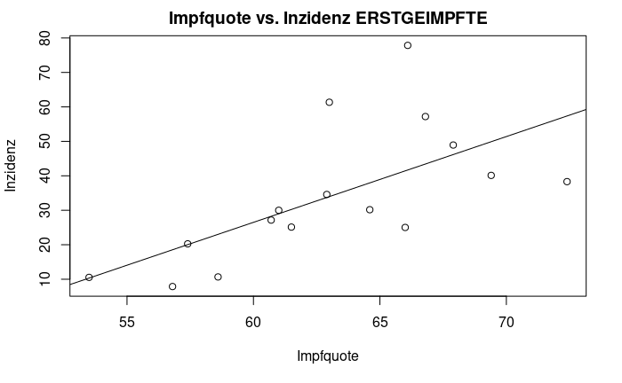

```r
plot(x=impfdaten$IQ1, y=impfdaten$Inzidenz, main="Impfquote vs. Inzidenz ERSTGEIMPFTE", xlab="Impfquote", ylab="Inzidenz")
abline(lm(impfdaten$Inzidenz~impfdaten$IQ1))
```

Dieses Streudiagramm zeigt den Zusammenhang zwischen Impfquoten und Inzidenzwerten der einzelnen Bundesländern gemäss o.g. Quelle. Berechnung des Korrelationskoeffizenten (>0,5 -> hohe Korrelation):

[output not shown]

````
```
[1] 0.642983
```
````

Ergebnis: Hohe Korrelation zwischen Quote Erstimpfung und Inzidenz

Signifikanztest / Ermittlung des p-Wertes;

```r
cor.test(impfdaten$Inzidenz, y = impfdaten$IQ1)$p.value
```

```
[1] 0.007216055
```

Das Ergebnis ist signifikant

**Analyse “Vollständige” Impfung**

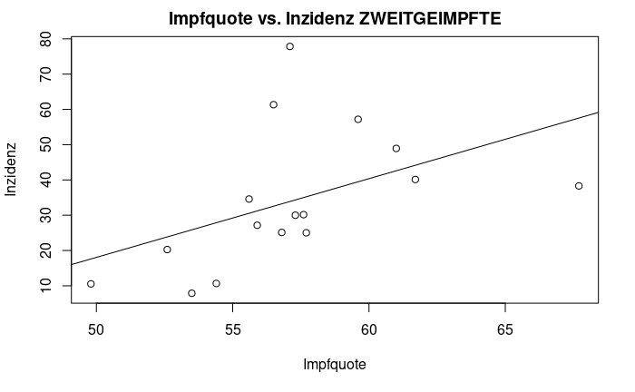

```r
plot(x=impfdaten$IQ2, y=impfdaten$Inzidenz, main="Impfquote vs. Inzidenz ZWEITGEIMPFTE", xlab="Impfquote", ylab="Inzidenz")
abline(lm(impfdaten$Inzidenz~impfdaten$IQ2))
```

[output not shown]

````
```
[1] 0.4710244
```
````

Ergebnis: schwache Korrelation zwischen Impfquote und Inzidenz

```r
cor.test(impfdaten$Inzidenz, y = impfdaten$IQ2)$p.value
```

```
[1] 0.0655351
```

Das Ergebnis ist nicht signifikant zu Alpha < 0.05. Eine Korrelation bei den “vollständig” Geimpften ist also nicht nachweisbar.

**Diskussion**

Während bei der “vollständigen” Impfung kein Zusammenhang nachweisbar ist, hat es den Anschein, dass die Erstimpfung einen Einfluss auf auf Inzidenzwerte hat.

Werden (Erst-)geimpfte überhaupt weiterhin getestet? Die Praxis dazu lässt sich aus Medienberichten nicht klar einordnen. In der nationalen Teststrategie des Bundes wird jedenfalls keine Unterscheidung vorgenommen. Also ist ein Kausalzusammenhang nach jetzigem Kenntnisstand möglich.

Bevor jedoch seriöse Hypothesen über eine Kausalität aufgestellt werden können, muss diese Erkenntnis durch Analysen weiterer Mitteleuropäischer Länder reproduziert werden.

**Anhang / verwendeter Datensatz**

```r
print(impfdaten)
```

| RS | Bundesland | IQ1 | IQ2 | Inzidenz |
| --- | --- | --- | --- | --- |
| 8 | Baden-Württemberg | 61.0 | 57.3 | 29.998935 |
| 9 | Bayern | 60.7 | 55.9 | 27.154830 |
| 11 | Berlin | 63.0 | 56.5 | 61.343658 |
| 12 | Brandenburg | 57.4 | 52.6 | 20.262557 |
| 4 | Bremen | 72.4 | 67.7 | 38.314626 |
| 2 | Hamburg | 66.1 | 57.1 | 77.845320 |
| 6 | Hessen | 62.9 | 55.6 | 34.589255 |
| 13 | Mecklenburg-Vorpommern | 61.5 | 56.8 | 25.122222 |
| 3 | Niedersachsen | 66.0 | 57.7 | 25.019991 |
| 5 | Nordrhein-Westfalen | 66.8 | 59.6 | 57.195484 |

[output cut: 6 more lines]